# Seagrass Fish and Inverts

ZL Monteith & F Manning

2023-03-14

## Seagrass Fish and Inverts Data Package

This script loads, cleans, and combines the datasets required for the Hakai Nearshore: Seagrass Fish and Macroinvertebrate data package. All of these data are stored on the Hakai EIMS Data Portal.

**Notes for adding data:** When adding a new year’s worth of survey data, *do not replace the existing raw data files* in this data package with downloads for all years from the EIMS portal; rather, download *only* the new year’s raw data and *append* that to the existing raw data files. This is important because the existing raw data files have undergone a post-portal download QC and ongoing changes to the portal can/have created issues for those older years. The same thing should be done for retroactively adding missing data from previous years.

Bottom line: *always add to the existing raw data file rather than replace the whole file.*

### Setup

Clear work space prior to starting

```r
rm(list = ls())
```

Load necessary packages

```r
lapply(c("tidyverse",
         "lubridate",
         "magrittr",
         "DataCombine"),
       library,
       character.only = TRUE)
```

[output not shown]

### Load and tidy data

Load data

```r
fish <- read.csv("./raw-data/seagrass_fish.csv")
inverts <- read.csv("./raw-data/seagrass_inverts.csv")
events <- read.csv("./raw-data/seagrass_events.csv")
names <- read.csv("./raw-data/seagrass_names.csv")
namestofix <- read.csv("./raw-data/seagrass_namestofix.csv")
sites <- read.csv("./raw-data/seagrass_sites.csv")
```

Tidy column names

```r
events <- rename_with(events, tolower)
colnames(events) <- gsub("\\.", "_", colnames(events))

fish <-  rename_with(fish, tolower)
colnames(fish) <- gsub("\\.", "_", colnames(fish))
names(fish)[names(fish) == "transect_dist__m_"] <- "transect_dist_m"
names(fish)[names(fish) == "length__cm_"] <- "length_cm"

inverts <-  rename_with(inverts, tolower)
colnames(inverts) <- gsub("\\.", "_", colnames(inverts))
names(inverts)[names(inverts) == "transect_dist__m_"] <- "transect_dist_m"
names(inverts)[names(inverts) == "size__cm_"] <- "size_cm"
```

Portal issues caused some rows to be added instead of updated (Hakai IDs should not appear more than once), so remove duplicate/extra rows (issues resolved on portal–removed fix, but keeping code in case it crops up again)

```r
# fish <- fish %>% distinct() %>% filter(action == "")
#
# inverts <- inverts %>%
#  group_by(hakai_id) %>%
#  summarise_all(list(~ .[!is.na(.)][1])) %>%
#  relocate(hakai_id, .after = surveyor) %>%
#  filter(action == "") %>%
# as.data.frame()
```

Collected_start/end times for 2016 fish are appearing as 2012, so correct that

```r
fish$collected_start <- gsub("2012", "2016", fish$collected_start)
fish$collected_end <- gsub("2012", "2016", fish$collected_end)
```

### Fixing names

**NOTE:**

New divers, tenders, tender combos, or fish/invert species may require the list of accepted names (seagrass_names.csv) to be updated.

New typos/misspellings may require the list of name corrections (seagrass_namestofix.csv) to be updated.

#### Fixing names: Species

Fix species names in both data sets so there aren’t multiple names for a single species

```r
# replacement using FindReplace
fish <- FindReplace(fish, "species", namestofix, from = "fish_name", to = "fish_replace", exact = TRUE, vector = FALSE)
```

```
## Only exact matches will be replaced.
```

```r
inverts <- FindReplace(inverts, "species", namestofix, from = "inverts_name", to = "inverts_replace", exact = TRUE, vector = FALSE)
```

```
## Only exact matches will be replaced.
```

Use this code to check for anything that didn’t work; if needed, update “seagrass_names.csv” and/or “seagrass_namestofix.csv” and rerun

```r
# import list of accepted fish names
fishnames_good <- names$fish %>% data.frame
colnames(fishnames_good) <- "name"

# import list of accepted inverts names
invertsnames_good <- names$inverts %>% data.frame
colnames(invertsnames_good) <- "name"

# create list of fish names in data that need fixing
fishnames_tofix <- unique(fish$species) %>% sort %>% data.frame
colnames(fishnames_tofix) <- "name"
fishnames_tofix <- anti_join(fishnames_tofix, fishnames_good)
fishnames_tofix <- filter(fishnames_tofix, name != "no_obs")

# create list of inverts names in data that need fixing
invertsnames_tofix <- unique(inverts$species) %>% sort %>% data.frame
colnames(invertsnames_tofix) <- "name"
invertsnames_tofix <- anti_join(invertsnames_tofix, invertsnames_good)
invertsnames_tofix <- filter(invertsnames_tofix, name != "no_obs")

#print to view and remove from data
c(fishnames_tofix, invertsnames_tofix)
```

```
## $name
## [1] ""                               "three spine stickleback (thst)"
##
## $name
## character(0)
```

```r
remove(list = c("fishnames_good", "fishnames_tofix", "invertsnames_good", "invertsnames_tofix"))
```

Fix stragglers (special characters)

```r
# FindReplace had trouble with replacing names containing special characters
fish$species[fish$species == "three spine stickleback (thst)"] <- "threespine_stickleback"
```

#### Fixing names: Divers

Fix diver names (i.e. surveyors) in both data sets so there aren’t multiple names for the same person

```r
# replacement using FindReplace
fish <- FindReplace(fish, "surveyor", namestofix, from = "divers_name", to = "divers_replace", exact = TRUE, vector = FALSE)
```

```
## Only exact matches will be replaced.
```

```r
inverts <- FindReplace(inverts, "surveyor", namestofix, from = "divers_name", to = "divers_replace", exact = TRUE, vector = FALSE)
```

```
## Only exact matches will be replaced.
```

Use this code to check for anything that didn’t work; if needed, update “seagrass_names.csv” and/or “seagrass_namestofix.csv” and rerun

```r
# import list of acceptable surveyor names
diversnames_good <- names$divers %>% data.frame
colnames(diversnames_good) <- "name"

# create list of surveyor names in fish data that need fixing
diversnames_tofix_fish <- unique(fish$surveyor) %>% sort %>% data.frame
colnames(diversnames_tofix_fish) <- "name"
diversnames_tofix_fish <- anti_join(diversnames_tofix_fish, diversnames_good)
diversnames_tofix_fish <- filter(diversnames_tofix_fish, name != "no_obs")

# create list of inverts names in inverts data that need fixing
diversnames_tofix_inverts <- unique(inverts$surveyor) %>% sort %>% data.frame
colnames(diversnames_tofix_inverts) <- "name"
diversnames_tofix_inverts <- anti_join(diversnames_tofix_inverts, diversnames_good)
diversnames_tofix_inverts <- filter(diversnames_tofix_inverts, name != "no_obs")

#print to view and remove from data
c(diversnames_tofix_fish, diversnames_tofix_inverts)
```

```
## $name
## character(0)
##
## $name
## character(0)
```

```r
remove(list = c("diversnames_good", "diversnames_tofix_fish", "diversnames_tofix_inverts"))
```

#### Fixing names: Techs

Fix tech names (i.e. tender, dive supervisors) in both data sets so there aren’t multiple names for the same person

```r
# replacement using FindReplace
fish <- FindReplace(fish, "dive_supervisor", namestofix, from = "techs_name", to = "techs_replace", exact = TRUE, vector = FALSE)
```

```
## Only exact matches will be replaced.
```

```r
inverts <- FindReplace(inverts, "dive_supervisor", namestofix, from = "techs_name", to = "techs_replace", exact = TRUE, vector = FALSE)
```

```
## Only exact matches will be replaced.
```

Use this code to check for anything that didn’t work; if needed, update “seagrass_names.csv” and/or “seagrass_namestofix.csv” and rerun

```r
# import list of acceptable surveyor names
techsnames_good <- names$techs %>% data.frame
colnames(techsnames_good) <- "name"

# create list of surveyor names in fish data that need fixing
techsnames_tofix_fish <- unique(fish$dive_supervisor) %>% sort %>% data.frame
colnames(techsnames_tofix_fish) <- "name"
techsnames_tofix_fish <- anti_join(techsnames_tofix_fish, techsnames_good)
techsnames_tofix_fish <- filter(techsnames_tofix_fish, name != "no_obs")

# create list of inverts names in inverts data that need fixing
techsnames_tofix_inverts <- unique(inverts$dive_supervisor) %>% sort %>% data.frame
colnames(techsnames_tofix_inverts) <- "name"
techsnames_tofix_inverts <- anti_join(techsnames_tofix_inverts, techsnames_good)
techsnames_tofix_inverts <- filter(techsnames_tofix_inverts, name != "no_obs")

#print to view and remove from data
c(techsnames_tofix_fish, techsnames_tofix_inverts)
```

```
## $name
## character(0)
##
## $name
## character(0)
```

```r
remove(list = c("techsnames_good", "techsnames_tofix_fish", "techsnames_tofix_inverts"))
```

### Other miscellaneous fixes

```r
inverts$size_cm <- replace(inverts$size_cm, grepl("siphon", inverts$species), NA)
```

Convert all blank cells to NA and remove columns with all NA data

```r
fish <- fish %>% mutate_all(na_if,"") %>% discard(~all(is.na(.)))
inverts <- inverts %>% mutate_all(na_if,"") %>% discard(~all(is.na(.)))
```

## Data Quality Check

### Cross Reference Events

In order to ensure completeness of the fish and invertebrate data sets (i.e. all site visits are included), the data will be aggregated to the event level, and then cross referenced with the events data also loaded from the EIMS Portal. If all data are present, the fish and invertebrate events should match the Events table.

For each event (i.e. transect - site_id - level visit), there should be two fish surveys, and two invertebrate surveys.

```r
# aggregate fish to event level
fish_events <-
  fish %>%
  group_by(date, survey, site_id, surveyor, collected_start) %>%
  summarise(n_species_obs = n()) %>%
  ungroup() %>%
  group_by(date, survey, site_id) %>%
  summarise(n_fish_surveys = n())
```

```
## You can override using the `.groups` argument.
```

```r
# aggregate inverts to event level
inverts_events <-
  inverts %>%
  group_by(date, survey, site_id, surveyor, collected_start) %>%
  summarise(n_species_obs = n()) %>%
  ungroup() %>%
  group_by(date, survey, site_id) %>%
  summarise(n_inverts_surveys = n())
```

```
## You can override using the `.groups` argument.
```

```r
# clean and aggregate events
events_count <-
  events %>%
  group_by(date, survey, site_id) %>%
  summarise(n_events = n())  #
# join fish events with events; there should be two fish surveys for each event
fish_events_check <-
  right_join(fish_events, events_count) %>%
   # remove typo Koeye events still stuck in data portal
  filter(!grepl("KOEYE_ESTUARY_ESTUARY", survey),
         !grepl("KOEYE_ESTUARY ESTUARY", survey),
         !grepl("^KOEYE_KOEYE.*", site_id))
# join invert events with events; there should be two invert surveys for each event
inverts_events_check <-
  right_join(inverts_events, events_count) %>%
   # remove typo Koeye events still stuck in data portal
  filter(!grepl("KOEYE_ESTUARY_ESTUARY", survey),
         !grepl("KOEYE_ESTUARY ESTUARY", survey),
         !grepl("^KOEYE_KOEYE.*", site_id))
# subset out events without the appropriate number of fish surveys
## all data missing (both surveys)
fish_2surveys_missing <-
  fish_events_check %>%
  filter(is.na(n_fish_surveys))

## one survey missing
fish_1survey_missing <-
  fish_events_check %>%
  filter(n_fish_surveys == 1)

## too many surveys; possibly entered twice, or mislabelled
fish_too_many_surveys <-
  fish_events_check %>%
  filter(n_fish_surveys > 2)

## join all fish events needing QC
fish_events_to_QC <-
  rbind(fish_2surveys_missing,
        fish_1survey_missing,
        fish_too_many_surveys) %>%
  mutate(issue = case_when(is.na(n_fish_surveys) ~ "both surveys missing",
                           n_fish_surveys == 1 ~ "one survey missing",
                           n_fish_surveys > 2 ~ "too many surveys")) %>%

## 2015 data not in the data portal currently
  filter(year(date) != 2015) %>%

## For 2018 onward, no fish and invert surveys conducted for Goose SE, McMullin, and Triquet
  filter(!(year(date) >= 2018 & survey == "GOOSE_SOUTHEAST"),
           !(year(date) >= 2018 & survey == "MCMULLIN_NORTH"),
             !(year(date) >= 2018 & survey == "MCMULLIN_SOUTH"),
               !(year(date) >= 2018 & survey =="TRIQUET_NORTH"),
                 !(year(date) >= 2018 & survey =="TRIQUET_BAY"))

# subset out events without the appropriate number of invert surveys
## all data missing (both surveys)
inverts_2surveys_missing <-
  inverts_events_check %>%
  filter(is.na(n_inverts_surveys))

## one survey missing
inverts_1survey_missing <-
  inverts_events_check %>%
  filter(n_inverts_surveys == 1)

## too many surveys; possibly entered twice, or mislabelled
inverts_too_many_surveys <-
  inverts_events_check %>%
  filter(n_inverts_surveys > 2)

## join all invert events needing QC
inverts_events_to_QC <-
  rbind(inverts_2surveys_missing,
        inverts_1survey_missing,
        inverts_too_many_surveys) %>%
  mutate(issue = case_when(is.na(n_inverts_surveys) ~ "both surveys missing",
                           n_inverts_surveys == 1 ~ "one survey missing",
                           n_inverts_surveys > 2 ~ "too many surveys")) %>%

## 2015 data not in the data portal currently
  filter(year(date) != 2015) %>%

## For 2018 onward, no fish and invert surveys conducted for Goose SE, McMullin, and Triquet
  filter(!(year(date) >= 2018 & survey == "GOOSE_SOUTHEAST"),
           !(year(date) >= 2018 & survey == "MCMULLIN_NORTH"),
             !(year(date) >= 2018 & survey == "MCMULLIN_SOUTH"),
               !(year(date) >= 2018 & survey =="TRIQUET_NORTH"),
                 !(year(date) >= 2018 & survey =="TRIQUET_BAY"))

## Save `fish_events_to_QC` and `inverts_events_to_QC` to .csv:
write.csv(fish_events_to_QC, "./output/fish_events_to_QC.csv")
write.csv(inverts_events_to_QC, "./output/inverts_events_to_QC.csv")

# Remove temporary data frames from environment
remove(list = c("events_count", "fish_1survey_missing", "fish_2surveys_missing", "fish_events", "fish_events_check", "fish_too_many_surveys", "inverts_1survey_missing", "inverts_2surveys_missing", "inverts_events", "inverts_events_check", "inverts_too_many_surveys"))
```

### More miscellaneous fixes

Check for discrepancies between date and collected_start/end (collected_start/end typically contain the correct date, but check for entering mistakes).

Since some event dates are incorrect, replace “date” with collected_start/end date here:

```r
fish$datecheck <- as.Date(fish$collected_start) %>% as.character()
fishdatecheck <- fish %>% filter(date != datecheck) # 2019-2022 confirmed that collected_start/end contain correct dates, still need to check other dates
fish$date <- ifelse(fish$date != fish$datecheck, fish$datecheck, fish$date)
fish <- subset(fish, select = -datecheck)
remove(fishdatecheck)

inverts$datecheck <- as.Date(inverts$collected_start) %>% as.character()
invertsdatecheck <- inverts %>% filter(date != datecheck) # 2019-2021 confirmed that collected_start/end contain correct dates, still need to check other dates
inverts$date <- ifelse(inverts$date != inverts$datecheck, inverts$datecheck, inverts$date)
inverts <- subset(inverts, select = -datecheck)
remove(invertsdatecheck)
```

New rows added to 2021 inverts data set on portal via excel file missing surveyor name; fix that here

```r
inverts$surveyor <- replace(inverts$surveyor, grepl("MGINV48083", inverts$hakai_id), "derek")
inverts$surveyor <- replace(inverts$surveyor, grepl("MGINV48084", inverts$hakai_id), "zach")
inverts$surveyor <- replace(inverts$surveyor, grepl("MGINV48085", inverts$hakai_id), "derek")
```

## Adding Data Quality Flags

### QC flagging - fish

Check fish lengths for suspicious values, using Q-Q plots to look at data values vs. quantiles:

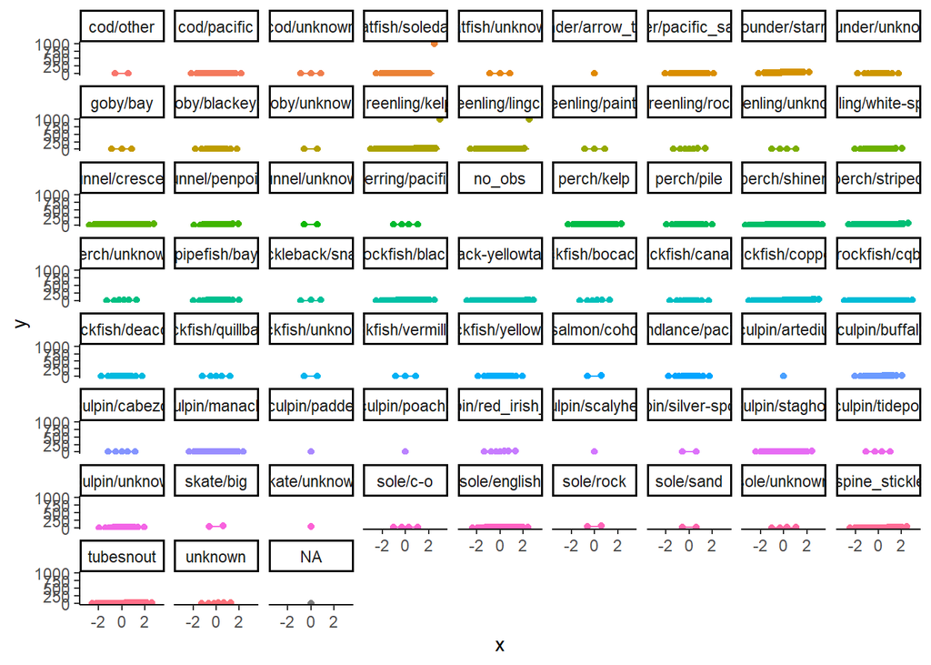

```r
# create qqplot for lengths
fishlengths_qqplot <- fish %>%
  ggplot(aes(col = species)) +
  stat_qq(aes(sample = length_cm)) +
  stat_qq_line(aes(sample = length_cm)) +
  facet_wrap( ~ species) +
  theme_classic() +
  theme(legend.position = "none")
fishlengths_qqplot
```

Looks like there might some fishy-looking fish lengths so let’s do some flagging

```r
# create working fish length data frame with just relevant data, including mean and SD
fishlengths <- fish %>%
  filter(!is.na(quantity)) %>%
  uncount(quantity) %>%
  select(hakai_id, species, length_cm) %>%
  left_join(fish %>%
  group_by(species) %>%
  summarise(mean = mean(length_cm, na.rm = T),
            sd = sd(length_cm, na.rm = T))) %>%
  unique()
# make QC flag bounds
fishlengths$upper99 <- fishlengths$mean + 2.5*fishlengths$sd
fishlengths$lower99 <- fishlengths$mean - 2.5*fishlengths$sd
fishlengths$upper95 <- fishlengths$mean + 2*fishlengths$sd
fishlengths$lower95 <- fishlengths$mean - 2*fishlengths$sd

# assign QC flags
fishlengths$qc_flag_lengths <- ifelse(fishlengths$length_cm < fishlengths$lower99, "SVD",
                                     ifelse(fishlengths$length_cm < fishlengths$lower95, "SVC",
                                             ifelse(fishlengths$length_cm < fishlengths$upper95, "AV",
                                                     ifelse(fishlengths$length_cm < fishlengths$upper99, "SVC", "SVD"))))

# merge QC flags back into OG fish data frame
fish <- left_join(fish, (select(fishlengths, "hakai_id", "qc_flag_lengths")), on = "hakai_id")
# remove temporary data frame
remove(fishlengths)
```

Check fish abundances for suspicious values:

```r
# note that for abundance, we'll want to group quantity by species and transects (i.e. unique combos of site_id, date, and surveyor) to look at average quantity per transect

# create new variable for transect, merging site_id, date, and surveyor together
fish$transect <- paste(fish$site_id, fish$date, fish$surveyor, sep = "_")

# create working fish length data frame with just relevant data, including mean and SD
fishabunds <- fish %>%
  filter(!is.na(quantity)) %>%
  select(hakai_id, transect, species, quantity) %>%
  left_join(fish %>%
  group_by(transect, species) %>%
  summarise(mean = mean(quantity, na.rm = T),
            sd = sd(quantity, na.rm = T)))
# make QC flags bounds
fishabunds$upper99 <- fishabunds$mean + 2.5*fishabunds$sd
fishabunds$lower99 <- fishabunds$mean - 2.5*fishabunds$sd
fishabunds$upper95 <- fishabunds$mean + 2*fishabunds$sd
fishabunds$lower95 <- fishabunds$mean - 2*fishabunds$sd

# assign QC flags
fishabunds$qc_flag_abunds <- ifelse(fishabunds$quantity < fishabunds$lower99, "SVD",
                                     ifelse(fishabunds$quantity < fishabunds$lower95, "SVC",
                                             ifelse(fishabunds$quantity < fishabunds$upper95, "AV",
                                                     ifelse(fishabunds$quantity < fishabunds$upper99, "SVC", "SVD"))))

# merge QC flags back into OG fish data frame and remove transects column
fish <- left_join(fish, (select(fishabunds, "hakai_id", "qc_flag_abunds")), on = "hakai_id")
fish <- subset(fish, select = -(transect))

#remove temporary data frame
remove(fishabunds)
```

### QC flagging - inverts

Check inverts sizes for suspicious values, using Q-Q plots to look at data values vs. quantiles:

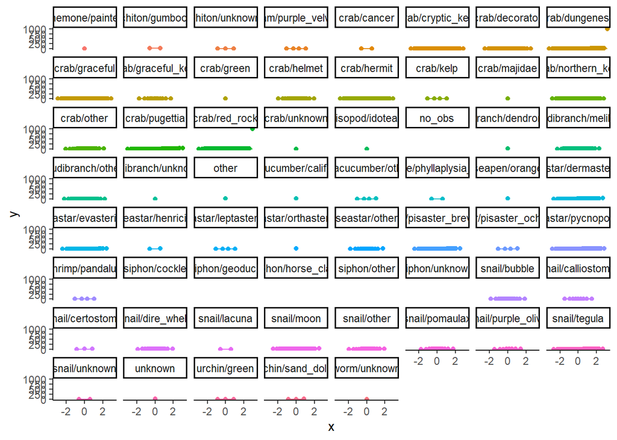

```r
# create qqplot for lengths
invertssize_qqplot <- inverts %>%
  ggplot(aes(col = species)) +
  stat_qq(aes(sample = size_cm)) +
  stat_qq_line(aes(sample = size_cm)) +
  facet_wrap( ~ species) +
  theme_classic() +
  theme(legend.position = "none")
invertssize_qqplot
```

```r
# create working inverts size data frame with just relevant data, including mean and SD
invertssizes <- inverts %>%
  filter(!is.na(quantity)) %>%
  uncount(quantity) %>%
  select(hakai_id, species, size_cm) %>%
  left_join(inverts %>%
  group_by(species) %>%
  summarise(mean = mean(size_cm, na.rm = T),
            sd = sd(size_cm, na.rm = T))) %>%
  unique()
# make QC flags bounds
invertssizes$upper99 <- invertssizes$mean + 2.5*invertssizes$sd
invertssizes$lower99 <- invertssizes$mean - 2.5*invertssizes$sd
invertssizes$upper95 <- invertssizes$mean + 2*invertssizes$sd
invertssizes$lower95 <- invertssizes$mean - 2*invertssizes$sd

# add QC flags
invertssizes$qc_flag_sizes <- ifelse(invertssizes$size_cm < invertssizes$lower99, "SVD",
                                     ifelse(invertssizes$size_cm < invertssizes$lower95, "SVC",
                                             ifelse(invertssizes$size_cm < invertssizes$upper95, "AV",
                                                     ifelse(invertssizes$size_cm < invertssizes$upper99, "SVC", "SVD"))))

# merge QC flags back into OG inverts data frame
inverts <- left_join(inverts, (select(invertssizes, "hakai_id", "qc_flag_sizes")), on = "hakai_id")
#remove temporary data frame
remove(invertssizes)
```

Check inverts abundances for suspicious values:

```r
# note that for abundance, we'll want to group quantity by species and transects (i.e. unique combos of site_id, date, and surveyor) to look at average quantity per transect

# create new variable for transect, merging site_id, date, and surveyor together
inverts$transect <- paste(inverts$site_id, inverts$date, inverts$surveyor, sep = "_")

# create working inverts length data frame with just relevant data, including mean and SD
invertsabunds <- inverts %>%
  filter(!is.na(quantity)) %>%
  select(hakai_id, transect, species, quantity) %>%
  left_join(inverts %>%
  group_by(transect, species) %>%
  summarise(mean = mean(size_cm, na.rm = T),
            sd = sd(size_cm, na.rm = T)))
# make QC flags bounds
invertsabunds$upper99 <- invertsabunds$mean + 2.5*invertsabunds$sd
invertsabunds$lower99 <- invertsabunds$mean - 2.5*invertsabunds$sd
invertsabunds$upper95 <- invertsabunds$mean + 2*invertsabunds$sd
invertsabunds$lower95 <- invertsabunds$mean - 2*invertsabunds$sd

# add QC flags
invertsabunds$qc_flag_abunds <- ifelse(invertsabunds$quantity < invertsabunds$lower99, "SVD",
                                     ifelse(invertsabunds$quantity < invertsabunds$lower95, "SVC",
                                             ifelse(invertsabunds$quantity < invertsabunds$upper95, "AV",
                                                     ifelse(invertsabunds$quantity < invertsabunds$upper99, "SVC", "SVD"))))

# merge QC flags back into OG inverts data frame and remove transects column
inverts <- left_join(inverts, (select(invertsabunds, "hakai_id", "qc_flag_abunds")), on = "X")
inverts <- subset(inverts, select = -(transect))

#remove temporary data frame
remove(invertsabunds)
```

#### Join site metadata

Tidy up column and site names

```r
sites <- rename_with(sites, tolower)
colnames(sites) <- gsub("\\.", "_", colnames(sites))
sites <- subset(sites, project_name == "Seagrass" & gps_level == "transect")

sites$site_name <- toupper(sites$site_name)
sites$site_name <- gsub(" ", "_", sites$site_name)
sites$site_name <- gsub("\\.", "_", sites$site_name)
sites$site_name <- gsub("GOOSE_SE", "GOOSE_SOUTHEAST", sites$site_name)
sites$site_name <- gsub("GOOSE_SW", "GOOSE_SOUTHWEST", sites$site_name)

sites$point_name <- gsub(".*_", "", sites$point_name)
sites$point_name <- gsub("E", "EDGE", sites$point_name)
sites$point_name <- gsub("I", "INTERIOR", sites$point_name)
sites$point_name <- paste(sites$site_name, sites$point_name, sep = "_")
```

Join site metadata onto data sets

```r
fish <- left_join(fish, (select(sites, "point_name", "substrate", "decimal_lat", "decimal_long", "end_transect_decimal_lat", "end_transect_decimal_lon")), by = c("site_id" = "point_name"))

inverts <- left_join(inverts, (select(sites, "point_name", "substrate", "decimal_lat", "decimal_long", "end_transect_decimal_lat", "end_transect_decimal_lon")), by = c("site_id" = "point_name"))
```

## Data output

Everything from 2019-2021 passes event-level QC; add earlier years later once rest of QC is sorted

```r
fish <- fish %>% filter((year(date) >= 2019))
inverts <- inverts %>% filter((year(date) >= 2019))
```

Save into finished, usable data sets

```r
write.csv(fish, "./output/seagrass_fish_survey.csv")
write.csv(inverts,"./output/seagrass_inverts_survey.csv")
```